# Topic: Choosing Right Batch Size

In this research, we will get intuition when choosing the batch size parameter. Batch size is very important for model training because when you decide the batch size parameter actually you decide how cost function will be. For example if you choose too big batch size your model will try to learn many samples each epoch and it mean each epoch your model take very small step. Nevertheless , this is not a bad sitution for some models but choosing too big batch size will increase the possibility of catching local minima point.

# Dataset

Our dataset will be very simple dataset. We will use house prices dataset. Firstly, we will check the usability of dataset.

Dataset Source: https://www.kaggle.com/harlfoxem/housesalesprediction

```python
import pandas as pd
import numpy as np
import matplotlib.pyplot as plt

#Importing the required modules
```

```python
dataset = pd.read_csv('data.csv') #importing dataset
```

```python
dataset #Checking the dataset
```

|  | id | date | price | bedrooms | bathrooms | sqft_living | sqft_lot | floors | waterfront | view | ... | grade | sqft_above | sqft_basement | yr_built | yr_renovated | zipcode | lat | long | sqft_living15 | sqft_lot15 |
| --- | --- | --- | --- | --- | --- | --- | --- | --- | --- | --- | --- | --- | --- | --- | --- | --- | --- | --- | --- | --- | --- |
| 0 | 7129300520 | 20141013T000000 | 221900.0 | 3 | 1.00 | 1180 | 5650 | 1.0 | 0 | 0 | ... | 7 | 1180 | 0 | 1955 | 0 | 98178 | 47.5112 | -122.257 | 1340 | 5650 |
| 1 | 6414100192 | 20141209T000000 | 538000.0 | 3 | 2.25 | 2570 | 7242 | 2.0 | 0 | 0 | ... | 7 | 2170 | 400 | 1951 | 1991 | 98125 | 47.7210 | -122.319 | 1690 | 7639 |
| 2 | 5631500400 | 20150225T000000 | 180000.0 | 2 | 1.00 | 770 | 10000 | 1.0 | 0 | 0 | ... | 6 | 770 | 0 | 1933 | 0 | 98028 | 47.7379 | -122.233 | 2720 | 8062 |
| 3 | 2487200875 | 20141209T000000 | 604000.0 | 4 | 3.00 | 1960 | 5000 | 1.0 | 0 | 0 | ... | 7 | 1050 | 910 | 1965 | 0 | 98136 | 47.5208 | -122.393 | 1360 | 5000 |
| 4 | 1954400510 | 20150218T000000 | 510000.0 | 3 | 2.00 | 1680 | 8080 | 1.0 | 0 | 0 | ... | 8 | 1680 | 0 | 1987 | 0 | 98074 | 47.6168 | -122.045 | 1800 | 7503 |
| ... | ... | ... | ... | ... | ... | ... | ... | ... | ... | ... | ... | ... | ... | ... | ... | ... | ... | ... | ... | ... | ... |
| 21608 | 263000018 | 20140521T000000 | 360000.0 | 3 | 2.50 | 1530 | 1131 | 3.0 | 0 | 0 | ... | 8 | 1530 | 0 | 2009 | 0 | 98103 | 47.6993 | -122.346 | 1530 | 1509 |
| 21609 | 6600060120 | 20150223T000000 | 400000.0 | 4 | 2.50 | 2310 | 5813 | 2.0 | 0 | 0 | ... | 8 | 2310 | 0 | 2014 | 0 | 98146 | 47.5107 | -122.362 | 1830 | 7200 |
| 21610 | 1523300141 | 20140623T000000 | 402101.0 | 2 | 0.75 | 1020 | 1350 | 2.0 | 0 | 0 | ... | 7 | 1020 | 0 | 2009 | 0 | 98144 | 47.5944 | -122.299 | 1020 | 2007 |
| 21611 | 291310100 | 20150116T000000 | 400000.0 | 3 | 2.50 | 1600 | 2388 | 2.0 | 0 | 0 | ... | 8 | 1600 | 0 | 2004 | 0 | 98027 | 47.5345 | -122.069 | 1410 | 1287 |
| 21612 | 1523300157 | 20141015T000000 | 325000.0 | 2 | 0.75 | 1020 | 1076 | 2.0 | 0 | 0 | ... | 7 | 1020 | 0 | 2008 | 0 | 98144 | 47.5941 | -122.299 | 1020 | 1357 |

21613 rows × 21 columns

# Features

We have 21 feature for this dataset but we will use 13 feature of this dataset.

# Features we will use:

```python
dataX = np.array(dataset)[:,[3,4,5,6,7,8,9,10,11,12,13,18,19]].astype('float32') # Weeding out the data and converting float32 type
dataY = np.array(dataset)[:,2].astype('float32') # Selecting prices for y data and converting float32 type
```

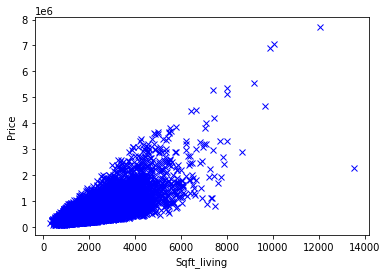

```python
plt.figure()
plt.plot(dataX[:,2] , dataY, 'bx')
plt.xlabel('Sqft_living')
plt.ylabel('Price')
plt.show()

#Checking the dataset with looking the relationship between sqft_living and price. We expect price generally increase with sqft_living
```

# Result: We can see the increment. Our data can be used for test.

# Data Preprocessing

```python
from sklearn.preprocessing import MinMaxScaler # We will use MinMaxScaler
from numpy.random import permutation

shuffler = permutation(len(dataX))
dataX = dataX[shuffler]
dataY = dataY[shuffler]

# Shuffling the dataset

xTrain = dataX[:len(dataX) * 80 // 100]
yTrain = dataY[:len(dataY) * 80 // 100]

xTest = dataX[len(dataX) * 80 // 100:]
yTest = dataY[len(dataY) * 80 // 100:]

# IMPORTANT NOTE : Firstly we must separate the datasets into category and then we must scale the data according to the train data

scalerX = MinMaxScaler()
scalerY = MinMaxScaler()
xTrain = scalerX.fit_transform(xTrain)
xTest = scalerX.transform(xTest)
yTrain = scalerY.fit_transform(yTrain.reshape(-1,1)).reshape(-1)
yTest = scalerY.transform(yTest.reshape(-1,1)).reshape(-1)

# We're scaling y data because we have very huge number in y data
```